# ml_exercise2

Pick a classiﬁcation dataset from the LIBSVM repository:

### Tasks:

### 1. Partition the dataset into a training set and a validation set.

Run a decision tree algorithm on the training set to generate a decision tree. Validate the decision tree on the validation dataset and report the total classiﬁcation error (i.e. 0/1 error). Repeat the experiment with a diﬀerent partition of training set/validation set. Plot the resulting tree. Are the resulting decision trees very diﬀerent? Explain why.

Advice: it can be convenient to set a maximum depth for the tree.

```python
from sklearn.datasets import load_svmlight_file
from sklearn import datasets, linear_model
from sklearn.model_selection import train_test_split
from sklearn.tree import DecisionTreeClassifier, export_graphviz
from sklearn.metrics import mean_squared_error, r2_score, accuracy_score
from IPython.display import SVG, display, Image
import graphviz
import numpy as np
import time
```

```python
def train_decision_tree(file_path, train_data_scale=0.8):
    '''
    TODO:
        train decision tree with special num of features
    Params:
        file_path: path of training data file
        train_data_scale: training data scale in all data
    Return:
        error value
    '''
    all_x, all_y = load_svmlight_file(file_path)
    train_x, validation_x, train_y, validation_y = train_test_split(all_x, all_y, test_size=1-train_data_scale)

    print('all data, train and validation shape: ', all_x.shape, all_y.shape,
          train_x.shape, train_y.shape, validation_x.shape, validation_y.shape)

    model = DecisionTreeClassifier(max_depth=10)

    start_time = time.time()
    model.fit(train_x, train_y) # Train the model using the training sets
    end_time = time.time()
    consume_time = end_time-start_time
    # print('consuming time: ', consume_time)
    pred_y = model.predict(validation_x)
    # print('pred_y: ', pred_y.shape)
    dot_data= export_graphviz(model, out_file=None)
    graph = graphviz.Source(dot_data)

    #display(SVG(graph.pipe(format='svg')))
    display(Image(graph.pipe(format='png')))

    accuracy = accuracy_score(validation_y, pred_y)
    eorro_val = 1-accuracy
    print('train_data_scale:%d ', train_data_scale, 'eorro:%.2f' % eorro_val)
    return eorro_val, consume_time
```

```python
file_path = './dataset/fourclass_scale'
```

```
all data, train and validation shape:  (862, 2) (862,) (689, 2) (689,) (173, 2) (173,)
```

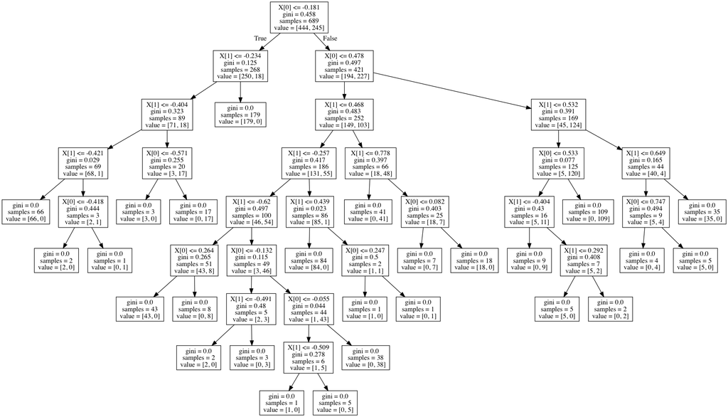

```
train_data_scale:%d  0.8 eorro:0.01
```

```python
eorro_val, consume_times = train_decision_tree(file_path, train_data_scale=0.8)
```

```
all data, train and validation shape:  (862, 2) (862,) (603, 2) (603,) (259, 2) (259,)
```

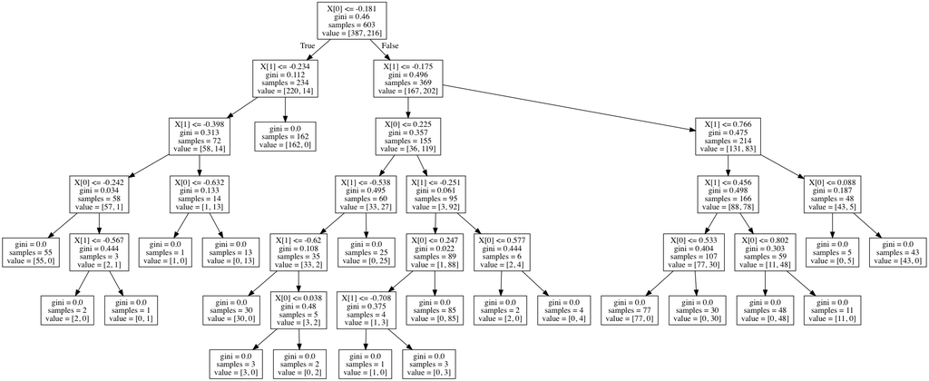

```
train_data_scale:%d  0.7 eorro:0.03
```

```python
eorro_val, consume_times = train_decision_tree(file_path, train_data_scale=0.70)
```

```
all data, train and validation shape:  (862, 2) (862,) (517, 2) (517,) (345, 2) (345,)
```

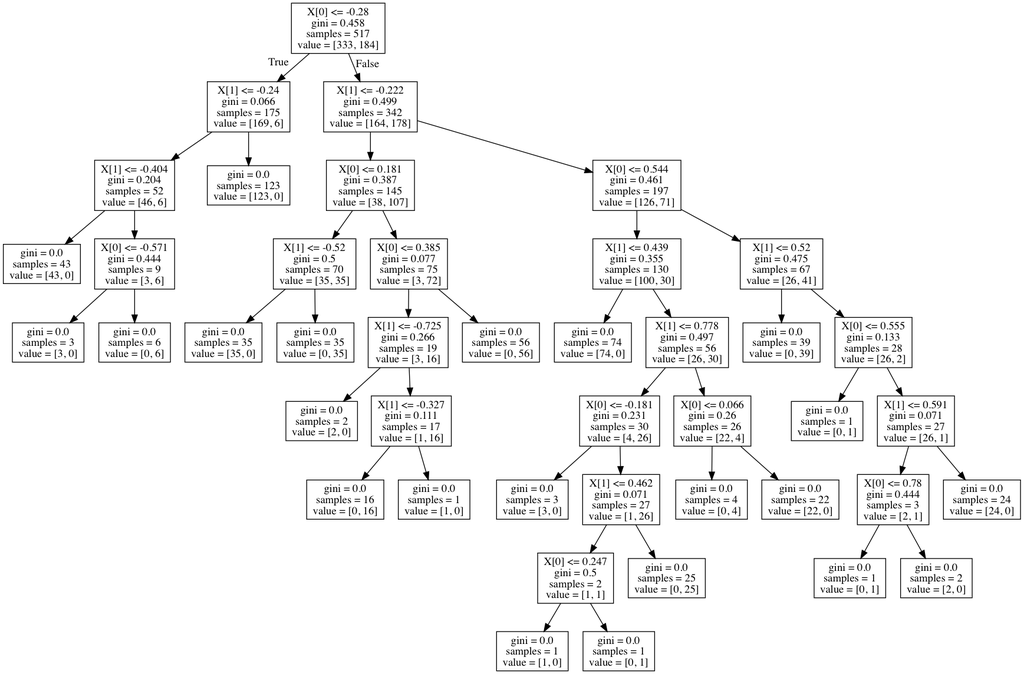

```
train_data_scale:%d  0.6 eorro:0.01
```

```python
eorro_val, consume_times = train_decision_tree(file_path, train_data_scale=0.6)
```

- Are the resulting decision trees very diﬀerent? Explain why.

| train_data | validation_data | error |
| --- | --- | --- |
| 80% | 20% | 0.01 |
| 70% | 30% | 0.03 |
| 60% | 40% | 0.01 |

Yes, the resulting decision trees with a differnt partition of training set/validation set are very different. Because the Decision Classification Tree with CART method is used in the experiment. In CART method Gini index(Gini impurity) is a measure of how often a randomly chosen element from the set would be incorrectly labeled.The Gini impurity can be computed by summing the probability \begin{align} {\displaystyle \sum _{k\neq i}p_{k}=1-p_{i}} \end{align} of a mistake in categorizing that item. Class i in the set maybe different by partition of training set/validation set and the classificaiton is also been by different training dataset.

### 2. Run SVM to train a classiﬁer, using a radial basis function as a kernel function.

Apply cross-validation to evaluate diﬀerent combinations of values of the model parameters (box constraint C and kernel parameter γ). How sensitive is the cross-validation error to changes in C and γ? Choose the combination of C and γ that minimizes the cross-validation error, train the SVM on the entire dataset and report the total classiﬁcation error. Advice: use a logaritmic range for parameter γ.

```python
from sklearn.svm import SVC
from sklearn.model_selection import cross_val_score, GridSearchCV
from sklearn.datasets import load_svmlight_file
from sklearn import datasets, linear_model
from sklearn.tree import DecisionTreeClassifier, export_graphviz
from sklearn.metrics import mean_squared_error, r2_score, accuracy_score
from IPython.display import SVG, display, Image
import numpy as np
import time
```

```python
def train_best_svm(file_path):
    '''
    TODO:
        train the svm best parammeters with cross-validation
    Params:
        file_path: path of training data file
    Return:
    '''
    train_x, train_y = load_svmlight_file(file_path)
    print('train shape: ', train_x.shape, train_y.shape)

    model = SVC(class_weight='balanced')
    params_grid = {
        'C': [0.1, 1, 10],
        'gamma': [0.01, 0.1, 1],
        'kernel':['rbf']
    }

    start_time = time.time()
    grid_model = GridSearchCV(model, param_grid=params_grid, cv=5)
    grid_model.fit(train_x[:5000], train_y[:5000])

    end_time = time.time()
    consume_time = end_time-start_time

    print('consume_time=', consume_time)
    print('best_params_=', grid_model.best_params_)
    print('best_score_',  grid_model.best_score_, "\n")
    print('split0_test_score=', grid_model.cv_results_["split0_test_score"], "\n")
    print('split1_test_score=', grid_model.cv_results_["split1_test_score"], "\n")
    print('split2_test_score=', grid_model.cv_results_["split2_test_score"])
    return
```

```python
train_best_svm(file_path)
```

```
('train shape: ', (862, 2), (862,))
('consume_time=', 0.8363180160522461)
('best_params_=', {'kernel': 'rbf', 'C': 10, 'gamma': 1})
('best_score_', 0.9605568445475638, '\n')
('split0_test_score=', array([0.66473988, 0.69364162, 0.75144509, 0.69942197, 0.69364162,
       0.83236994, 0.69364162, 0.79190751, 0.95953757]), '\n')
('split1_test_score=', array([0.65895954, 0.73410405, 0.76300578, 0.73410405, 0.76878613,
       0.86705202, 0.7283237 , 0.82080925, 0.95375723]), '\n')
('split2_test_score=', array([0.65697674, 0.75      , 0.75581395, 0.74418605, 0.75581395,
       0.86627907, 0.75      , 0.79651163, 0.97674419]))
```

- From above result of cross-validation, the cross-validation error is so sensitive with C and gamma. The minimizes the cross-validation error is 0.04 where the value of C is 10 and the value of gamma is 1.

#### Choose the combination of C and γ that minimizes the cross-validation error, train the SVM on the entire dataset and report the total classiﬁcation error.

```python
def train_svm(file_path, C=1, gamma=1):
    '''
    TODO:
        train svm with C and gamma
    Params:
        file_path: path of training data file
    Return:
        error value
    '''
    train_x, train_y = load_svmlight_file(file_path)
    print('train shape: ', train_x.shape, train_y.shape)

    model = SVC(kernel='rbf', C=C, gamma=gamma)

    start_time = time.time()
    scores = cross_val_score(model, train_x, train_y, cv=5)

    end_time = time.time()
    consume_time = end_time-start_time

    print('C=', C, ' gamma=', gamma, 'consuming time=', consume_time, ' accuray=%.2f' % scores.mean())
    return scores.mean()
```

```python
train_svm(file_path, C=10, gamma=1)
```

```
('train shape: ', (862, 2), (862,))
('C=', 10, ' gamma=', 1, 'consuming time=', 0.08788585662841797, ' accuray=0.97')
```

```
0.9733163059551014
```

### 3. Train a Multi-Layer perceptron using the cross-entropy loss with L2 regularization (weight decay penalty).

In other words, the activation function equals the logistic function. Plot curves of the training and validation error as a function of the penalty strength α. How do the curves behave? Explain why.

```python
from sklearn.neural_network import MLPClassifier
from sklearn.datasets import load_svmlight_file
from sklearn import datasets, linear_model
from sklearn.model_selection import train_test_split
from sklearn.tree import DecisionTreeClassifier, export_graphviz
from sklearn.metrics import mean_squared_error, r2_score, accuracy_score
from IPython.display import SVG, display, Image
import numpy as np
import time
```

```python
def train_multi_nn(file_path, alpha=0.0001, train_data_scale=0.7):
    '''
    TODO:
        train multi layer NN with logistic and L2 Regularization Method
    Params:
        file_path: path of training data file
        alpha: L2 penalty
    Return:
        error value
    '''
    all_x, all_y = load_svmlight_file(file_path)
    train_x, validation_x, train_y, validation_y = train_test_split(all_x, all_y, test_size=1-train_data_scale)

    #print('train and validation shape: ', train_x.shape, train_y.shape, validation_x.shape, validation_y.shape)

    model = MLPClassifier(solver='lbfgs', activation='logistic', alpha=alpha, hidden_layer_sizes=(60, 10))
    model.fit(train_x, train_y)

    validation_y_pred = model.predict(validation_x)
    train_y_pred = model.predict(train_x)

    validation_acc = accuracy_score(validation_y, validation_y_pred)
    train_acc = accuracy_score(train_y, train_y_pred)

    validation_error = 1-validation_acc
    train_error = 1-train_acc
    print('alpha=', alpha, 'validation_error:%.2f' % validation_error, 'train_error:%.2f' % train_error)
    return train_error, validation_error
```

```python
file_path = './dataset/connect-4'
train_error, validation_error = train_multi_nn(file_path)
```

```
('alpha=', 0.0001, 'validation_error:0.19', 'train_error:0.17')
```

```python
alphas = [0.00001, 0.0001, 0.001, 0.01, 0.1, 1]
train_error_list = []
validation_error_list = []
for alpha in alphas:
    train_error, validation_error = train_multi_nn(file_path, alpha)
    train_error_list.append(train_error)
    validation_error_list.append(validation_error)
```

[output not shown]

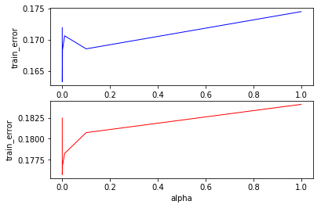

```python
%matplotlib inline
import matplotlib.pyplot as plt

plt.figure()
plt.subplot(211)
plt.plot(alphas, train_error_list, color='blue', linewidth=1)
plt.xlabel('alpha')
plt.ylabel('train_error')

plt.subplot(212)
plt.plot(alphas, validation_error_list, color='red', linewidth=1)
plt.xlabel('alpha')
plt.ylabel('train_error')

plt.show()
```